# index

## Patrick Mugisha, "On my honor, as a student, I have neither given nor received unauthorized aid on this academic work."

```python
import pingouin as pg
import numpy as np
import seaborn as sns
import matplotlib.pyplot as plt
%matplotlib inline
import pandas as pd
from IPython.display import Image
pd.set_option('display.max_columns', None)  # helps see all column headers
```

```python
df=pd.read_csv('data/Chapter09DataSet_Training.csv')
df.head()
```

|  | Age | Marital_Status | Gender | Weight_Category | Cholesterol | Stress_Management | Trait_Anxiety | 2nd_Heart_Attack |
| --- | --- | --- | --- | --- | --- | --- | --- | --- |
| 0 | 60 | 2 | 0 | 1 | 150 | 1 | 50 | Yes |
| 1 | 69 | 2 | 1 | 1 | 170 | 0 | 60 | Yes |
| 2 | 52 | 1 | 0 | 0 | 174 | 1 | 35 | No |
| 3 | 66 | 2 | 1 | 1 | 169 | 0 | 60 | Yes |
| 4 | 70 | 3 | 0 | 1 | 237 | 0 | 65 | Yes |

# Section 1. Exploratory Data Analysis - Correlation (Healthcare Analytics)

## Q1. What is the goal of correlation analysis ?

- The goal of correlation analysis is to find the similarities and/or differences between two or more datasets predicting the same y variable but with different or slightly adjusted independent variables.

## Q2. Perform correlation analysis. This dataset contains categorical values (e.g., Stress_Management, Weight_Category). What types of data transformation did you have to do for correlation analysis?

```python
df.info()
```

```
<class 'pandas.core.frame.DataFrame'>
RangeIndex: 138 entries, 0 to 137
Data columns (total 8 columns):
 #   Column             Non-Null Count  Dtype
---  ------             --------------  -----
 0   Age                138 non-null    int64
 1   Marital_Status     138 non-null    int64
 2   Gender             138 non-null    int64
 3   Weight_Category    138 non-null    int64
 4   Cholesterol        138 non-null    int64
 5   Stress_Management  138 non-null    int64
 6   Trait_Anxiety      138 non-null    int64
 7   2nd_Heart_Attack   138 non-null    object
dtypes: int64(7), object(1)
memory usage: 8.8+ KB
```

```python
# the output is partial correlation because 2nd_Heart_Attack is categorical and is ignored

df.corr()
```

|  | Age | Marital_Status | Gender | Weight_Category | Cholesterol | Stress_Management | Trait_Anxiety |
| --- | --- | --- | --- | --- | --- | --- | --- |
| Age | 1.000000 | 0.427159 | 0.076195 | 0.402007 | 0.395331 | -0.359295 | 0.667169 |
| Marital_Status | 0.427159 | 1.000000 | -0.033225 | 0.065402 | 0.273574 | -0.291773 | 0.238340 |
| Gender | 0.076195 | -0.033225 | 1.000000 | 0.448531 | 0.191354 | -0.241320 | 0.082007 |
| Weight_Category | 0.402007 | 0.065402 | 0.448531 | 1.000000 | 0.397702 | -0.347322 | 0.501244 |
| Cholesterol | 0.395331 | 0.273574 | 0.191354 | 0.397702 | 1.000000 | -0.405735 | 0.579485 |
| Stress_Management | -0.359295 | -0.291773 | -0.241320 | -0.347322 | -0.405735 | 1.000000 | -0.321362 |
| Trait_Anxiety | 0.667169 | 0.238340 | 0.082007 | 0.501244 | 0.579485 | -0.321362 | 1.000000 |

```python
# this code is used for finding unique values in 2nd_Heart_Attack column

df['2nd_Heart_Attack'].unique()
```

```
array(['Yes', 'No'], dtype=object)
```

```python
# this code creates dummy values for 2nd_Heart_Attack column

df=pd.get_dummies(df, columns=['2nd_Heart_Attack'])
df.head()
```

|  | Age | Marital_Status | Gender | Weight_Category | Cholesterol | Stress_Management | Trait_Anxiety | 2nd_Heart_Attack_No | 2nd_Heart_Attack_Yes |
| --- | --- | --- | --- | --- | --- | --- | --- | --- | --- |
| 0 | 60 | 2 | 0 | 1 | 150 | 1 | 50 | 0 | 1 |
| 1 | 69 | 2 | 1 | 1 | 170 | 0 | 60 | 0 | 1 |
| 2 | 52 | 1 | 0 | 0 | 174 | 1 | 35 | 1 | 0 |
| 3 | 66 | 2 | 1 | 1 | 169 | 0 | 60 | 0 | 1 |
| 4 | 70 | 3 | 0 | 1 | 237 | 0 | 65 | 0 | 1 |

```python
# perform correlation analysis again since we don't have categorical data anymore

df.corr()
```

|  | Age | Marital_Status | Gender | Weight_Category | Cholesterol | Stress_Management | Trait_Anxiety | 2nd_Heart_Attack_No | 2nd_Heart_Attack_Yes |
| --- | --- | --- | --- | --- | --- | --- | --- | --- | --- |
| Age | 1.000000 | 0.427159 | 0.076195 | 0.402007 | 0.395331 | -0.359295 | 0.667169 | -0.499182 | 0.499182 |
| Marital_Status | 0.427159 | 1.000000 | -0.033225 | 0.065402 | 0.273574 | -0.291773 | 0.238340 | -0.364978 | 0.364978 |
| Gender | 0.076195 | -0.033225 | 1.000000 | 0.448531 | 0.191354 | -0.241320 | 0.082007 | -0.317746 | 0.317746 |
| Weight_Category | 0.402007 | 0.065402 | 0.448531 | 1.000000 | 0.397702 | -0.347322 | 0.501244 | -0.730832 | 0.730832 |
| Cholesterol | 0.395331 | 0.273574 | 0.191354 | 0.397702 | 1.000000 | -0.405735 | 0.579485 | -0.506531 | 0.506531 |
| Stress_Management | -0.359295 | -0.291773 | -0.241320 | -0.347322 | -0.405735 | 1.000000 | -0.321362 | 0.439473 | -0.439473 |
| Trait_Anxiety | 0.667169 | 0.238340 | 0.082007 | 0.501244 | 0.579485 | -0.321362 | 1.000000 | -0.482548 | 0.482548 |
| 2nd_Heart_Attack_No | -0.499182 | -0.364978 | -0.317746 | -0.730832 | -0.506531 | 0.439473 | -0.482548 | 1.000000 | -1.000000 |
| 2nd_Heart_Attack_Yes | 0.499182 | 0.364978 | 0.317746 | 0.730832 | 0.506531 | -0.439473 | 0.482548 | -1.000000 | 1.000000 |

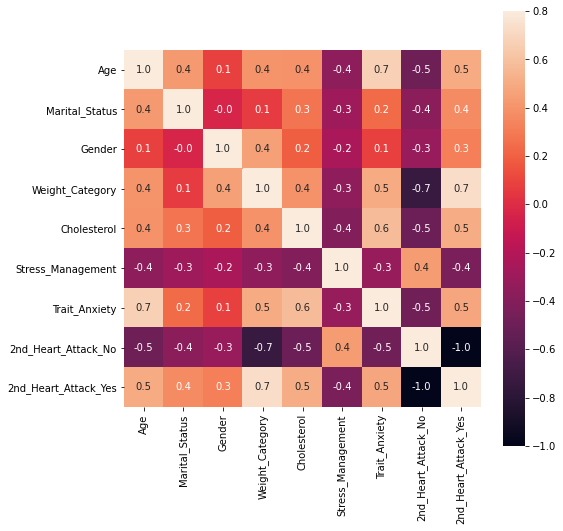

```python
# correlation plot

plt.figure(figsize=(8, 8))
sns.heatmap(df.corr(), vmax=.8, square=True, annot=True, fmt=".1f")
```

## Q2 b. What types of data transformation did you have to do for correlation analysis?

- 2nd_Heart_Attack is a string column and needs to be converted to number columns for correlation analysis using ETL.
- Created dummy variables for 2nd_Heart_Attack column.

## Q4. Describe the characteristics of people who are at risk of having 2nd heart attack.

```python
df1=pd.get_dummies(df, columns=['Age', 'Marital_Status', 'Gender', 'Weight_Category', 'Stress_Management', 'Trait_Anxiety'])
df1.head()
```

|  | Cholesterol | 2nd_Heart_Attack_No | 2nd_Heart_Attack_Yes | Age_42 | Age_48 | Age_49 | Age_50 | Age_51 | Age_52 | Age_53 | Age_54 | Age_55 | Age_57 | Age_58 | Age_59 | Age_60 | Age_61 | Age_62 | Age_63 | Age_64 | Age_65 | Age_66 | Age_67 | Age_68 | Age_69 | Age_70 | Age_71 | Age_72 | Age_73 | … |
| --- | --- | --- | --- | --- | --- | --- | --- | --- | --- | --- | --- | --- | --- | --- | --- | --- | --- | --- | --- | --- | --- | --- | --- | --- | --- | --- | --- | --- | --- | --- |
| 0 | 150 | 0 | 1 | 0 | 0 | 0 | 0 | 0 | 0 | 0 | 0 | 0 | 0 | 0 | 0 | 1 | 0 | 0 | 0 | 0 | 0 | 0 | 0 | 0 | 0 | 0 | 0 | 0 | 0 | … |
| 1 | 170 | 0 | 1 | 0 | 0 | 0 | 0 | 0 | 0 | 0 | 0 | 0 | 0 | 0 | 0 | 0 | 0 | 0 | 0 | 0 | 0 | 0 | 0 | 0 | 1 | 0 | 0 | 0 | 0 | … |
| 2 | 174 | 1 | 0 | 0 | 0 | 0 | 0 | 0 | 1 | 0 | 0 | 0 | 0 | 0 | 0 | 0 | 0 | 0 | 0 | 0 | 0 | 0 | 0 | 0 | 0 | 0 | 0 | 0 | 0 | … |
| 3 | 169 | 0 | 1 | 0 | 0 | 0 | 0 | 0 | 0 | 0 | 0 | 0 | 0 | 0 | 0 | 0 | 0 | 0 | 0 | 0 | 0 | 1 | 0 | 0 | 0 | 0 | 0 | 0 | 0 | … |
| 4 | 237 | 0 | 1 | 0 | 0 | 0 | 0 | 0 | 0 | 0 | 0 | 0 | 0 | 0 | 0 | 0 | 0 | 0 | 0 | 0 | 0 | 0 | 0 | 0 | 0 | 1 | 0 | 0 | 0 | … |

```python
df1corr=df1.corr()
df1corr.head(55)
```

|  | Cholesterol | 2nd_Heart_Attack_No | 2nd_Heart_Attack_Yes | Age_42 | Age_48 | Age_49 | Age_50 | Age_51 | Age_52 | Age_53 | Age_54 | Age_55 | Age_57 | Age_58 | Age_59 | Age_60 | Age_61 | Age_62 | Age_63 | Age_64 | Age_65 | Age_66 | Age_67 | Age_68 | Age_69 | Age_70 | Age_71 | Age_72 | Age_73 | … |
| --- | --- | --- | --- | --- | --- | --- | --- | --- | --- | --- | --- | --- | --- | --- | --- | --- | --- | --- | --- | --- | --- | --- | --- | --- | --- | --- | --- | --- | --- | --- |
| Cholesterol | 1.000000 | -0.506531 | 0.506531 | -0.139244 | -0.014329 | 0.009841 | -0.021910 | -0.035695 | -0.029065 | -0.065608 | -0.045706 | -0.207075 | -0.014329 | -0.147466 | 0.029032 | -0.190808 | -0.078833 | 4.455912e-02 | -0.246282 | 0.143775 | -0.094817 | -4.247352e-02 | 0.024770 | -0.068284 | -0.033725 | 0.238380 | 1.256301e-01 | 0.284828 | 0.223224 | … |
| 2nd_Heart_Attack_No | -0.506531 | 1.000000 | -1.000000 | 0.084206 | 0.084206 | 0.119523 | 0.146926 | 0.083892 | 0.182476 | -0.123038 | 0.139059 | 0.119523 | 0.084206 | 0.201632 | -0.168482 | 0.029676 | 0.095729 | 4.753494e-02 | 0.161781 | -0.091883 | 0.083892 | 8.422589e-02 | -0.175296 | 0.047535 | -0.196722 | -0.145239 | -7.416456e-02 | -0.168482 | -0.196722 | … |
| 2nd_Heart_Attack_Yes | 0.506531 | -1.000000 | 1.000000 | -0.084206 | -0.084206 | -0.119523 | -0.146926 | -0.083892 | -0.182476 | 0.123038 | -0.139059 | -0.119523 | -0.084206 | -0.201632 | 0.168482 | -0.029676 | -0.095729 | -4.753494e-02 | -0.161781 | 0.091883 | -0.083892 | -8.422589e-02 | 0.175296 | -0.047535 | 0.196722 | 0.145239 | 7.416456e-02 | 0.168482 | 0.196722 | … |
| Age_42 | -0.139244 | 0.084206 | -0.084206 | 1.000000 | -0.007299 | -0.010361 | -0.012736 | -0.014761 | -0.021194 | -0.010361 | -0.018215 | -0.010361 | -0.007299 | -0.022567 | -0.019749 | -0.019749 | -0.019749 | -1.273601e-02 | -0.019749 | -0.022567 | -0.014761 | -2.256660e-02 | -0.014761 | -0.012736 | -0.016565 | -0.018215 | -1.821497e-02 | -0.019749 | -0.016565 | … |
| Age_48 | -0.014329 | 0.084206 | -0.084206 | -0.007299 | 1.000000 | -0.010361 | -0.012736 | -0.014761 | -0.021194 | -0.010361 | -0.018215 | -0.010361 | -0.007299 | -0.022567 | -0.019749 | -0.019749 | -0.019749 | -1.273601e-02 | -0.019749 | -0.022567 | -0.014761 | -2.256660e-02 | -0.014761 | -0.012736 | -0.016565 | -0.018215 | -1.821497e-02 | -0.019749 | -0.016565 | … |
| Age_49 | 0.009841 | 0.119523 | -0.119523 | -0.010361 | -0.010361 | 1.000000 | -0.018078 | -0.020952 | -0.030083 | -0.014706 | -0.025854 | -0.014706 | -0.010361 | -0.032031 | -0.028032 | -0.028032 | -0.028032 | -1.807754e-02 | -0.028032 | -0.032031 | -0.020952 | -3.203111e-02 | -0.020952 | -0.018078 | -0.023513 | -0.025854 | -2.585438e-02 | -0.028032 | -0.023513 | … |
| Age_50 | -0.021910 | 0.146926 | -0.146926 | -0.012736 | -0.012736 | -0.018078 | 1.000000 | -0.025756 | -0.036980 | -0.018078 | -0.031782 | -0.018078 | -0.012736 | -0.039375 | -0.034459 | -0.034459 | -0.034459 | -2.222222e-02 | -0.034459 | -0.039375 | -0.025756 | -3.937496e-02 | -0.025756 | -0.022222 | -0.028904 | -0.031782 | -3.178209e-02 | -0.034459 | -0.028904 | … |
| Age_51 | -0.035695 | 0.083892 | -0.083892 | -0.014761 | -0.014761 | -0.020952 | -0.025756 | 1.000000 | -0.042860 | -0.020952 | -0.036835 | -0.020952 | -0.014761 | -0.045636 | -0.039938 | -0.039938 | -0.039938 | -2.575558e-02 | -0.039938 | -0.045636 | -0.029851 | -4.563562e-02 | -0.029851 | -0.025756 | -0.033499 | -0.036835 | -3.683547e-02 | -0.039938 | -0.033499 | … |
| Age_52 | -0.029065 | 0.182476 | -0.182476 | -0.021194 | -0.021194 | -0.030083 | -0.036980 | -0.042860 | 1.000000 | -0.030083 | -0.052889 | -0.030083 | -0.021194 | -0.065524 | -0.057344 | -0.057344 | -0.057344 | -3.698001e-02 | -0.057344 | -0.065524 | -0.042860 | -6.552390e-02 | -0.042860 | -0.036980 | -0.048099 | -0.052889 | -5.288859e-02 | -0.057344 | -0.048099 | … |
| Age_53 | -0.065608 | -0.123038 | 0.123038 | -0.010361 | -0.010361 | -0.014706 | -0.018078 | -0.020952 | -0.030083 | 1.000000 | -0.025854 | -0.014706 | -0.010361 | -0.032031 | -0.028032 | -0.028032 | -0.028032 | -1.807754e-02 | -0.028032 | -0.032031 | -0.020952 | -3.203111e-02 | -0.020952 | -0.018078 | -0.023513 | -0.025854 | -2.585438e-02 | -0.028032 | -0.023513 | … |
| Age_54 | -0.045706 | 0.139059 | -0.139059 | -0.018215 | -0.018215 | -0.025854 | -0.031782 | -0.036835 | -0.052889 | -0.025854 | 1.000000 | -0.025854 | -0.018215 | -0.056314 | -0.049284 | -0.049284 | -0.049284 | -3.178209e-02 | -0.049284 | -0.056314 | -0.036835 | -5.631383e-02 | -0.036835 | -0.031782 | -0.041338 | -0.045455 | -4.545455e-02 | -0.049284 | -0.041338 | … |
| Age_55 | -0.207075 | 0.119523 | -0.119523 | -0.010361 | -0.010361 | -0.014706 | -0.018078 | -0.020952 | -0.030083 | -0.014706 | -0.025854 | 1.000000 | -0.010361 | -0.032031 | -0.028032 | -0.028032 | -0.028032 | -1.807754e-02 | -0.028032 | -0.032031 | -0.020952 | -3.203111e-02 | -0.020952 | -0.018078 | -0.023513 | -0.025854 | -2.585438e-02 | -0.028032 | -0.023513 | … |
| Age_57 | -0.014329 | 0.084206 | -0.084206 | -0.007299 | -0.007299 | -0.010361 | -0.012736 | -0.014761 | -0.021194 | -0.010361 | -0.018215 | -0.010361 | 1.000000 | -0.022567 | -0.019749 | -0.019749 | -0.019749 | -1.273601e-02 | -0.019749 | -0.022567 | -0.014761 | -2.256660e-02 | -0.014761 | -0.012736 | -0.016565 | -0.018215 | -1.821497e-02 | -0.019749 | -0.016565 | … |
| Age_58 | -0.147466 | 0.201632 | -0.201632 | -0.022567 | -0.022567 | -0.032031 | -0.039375 | -0.045636 | -0.065524 | -0.032031 | -0.056314 | -0.032031 | -0.022567 | 1.000000 | -0.061058 | -0.061058 | -0.061058 | -3.937496e-02 | -0.061058 | -0.069767 | -0.045636 | -6.976744e-02 | -0.045636 | -0.039375 | -0.051214 | -0.056314 | -5.631383e-02 | -0.061058 | -0.051214 | … |
| Age_59 | 0.029032 | -0.168482 | 0.168482 | -0.019749 | -0.019749 | -0.028032 | -0.034459 | -0.039938 | -0.057344 | -0.028032 | -0.049284 | -0.028032 | -0.019749 | -0.061058 | 1.000000 | -0.053435 | -0.053435 | -3.445935e-02 | -0.053435 | -0.061058 | -0.039938 | -6.105761e-02 | -0.039938 | -0.034459 | -0.044820 | -0.049284 | -4.928356e-02 | -0.053435 | -0.044820 | … |
| Age_60 | -0.190808 | 0.029676 | -0.029676 | -0.019749 | -0.019749 | -0.028032 | -0.034459 | -0.039938 | -0.057344 | -0.028032 | -0.049284 | -0.028032 | -0.019749 | -0.061058 | -0.053435 | 1.000000 | -0.053435 | -3.445935e-02 | -0.053435 | -0.061058 | -0.039938 | -6.105761e-02 | -0.039938 | -0.034459 | -0.044820 | -0.049284 | -4.928356e-02 | -0.053435 | -0.044820 | … |
| Age_61 | -0.078833 | 0.095729 | -0.095729 | -0.019749 | -0.019749 | -0.028032 | -0.034459 | -0.039938 | -0.057344 | -0.028032 | -0.049284 | -0.028032 | -0.019749 | -0.061058 | -0.053435 | -0.053435 | 1.000000 | -3.445935e-02 | -0.053435 | -0.061058 | -0.039938 | -6.105761e-02 | -0.039938 | -0.034459 | -0.044820 | -0.049284 | -4.928356e-02 | -0.053435 | -0.044820 | … |
| Age_62 | 0.044559 | 0.047535 | -0.047535 | -0.012736 | -0.012736 | -0.018078 | -0.022222 | -0.025756 | -0.036980 | -0.018078 | -0.031782 | -0.018078 | -0.012736 | -0.039375 | -0.034459 | -0.034459 | -0.034459 | 1.000000e+00 | -0.034459 | -0.039375 | -0.025756 | -3.937496e-02 | -0.025756 | -0.022222 | -0.028904 | -0.031782 | -3.178209e-02 | -0.034459 | -0.028904 | … |
| Age_63 | -0.246282 | 0.161781 | -0.161781 | -0.019749 | -0.019749 | -0.028032 | -0.034459 | -0.039938 | -0.057344 | -0.028032 | -0.049284 | -0.028032 | -0.019749 | -0.061058 | -0.053435 | -0.053435 | -0.053435 | -3.445935e-02 | 1.000000 | -0.061058 | -0.039938 | -6.105761e-02 | -0.039938 | -0.034459 | -0.044820 | -0.049284 | -4.928356e-02 | -0.053435 | -0.044820 | … |
| Age_64 | 0.143775 | -0.091883 | 0.091883 | -0.022567 | -0.022567 | -0.032031 | -0.039375 | -0.045636 | -0.065524 | -0.032031 | -0.056314 | -0.032031 | -0.022567 | -0.069767 | -0.061058 | -0.061058 | -0.061058 | -3.937496e-02 | -0.061058 | 1.000000 | -0.045636 | -6.976744e-02 | -0.045636 | -0.039375 | -0.051214 | -0.056314 | -5.631383e-02 | -0.061058 | -0.051214 | … |
| Age_65 | -0.094817 | 0.083892 | -0.083892 | -0.014761 | -0.014761 | -0.020952 | -0.025756 | -0.029851 | -0.042860 | -0.020952 | -0.036835 | -0.020952 | -0.014761 | -0.045636 | -0.039938 | -0.039938 | -0.039938 | -2.575558e-02 | -0.039938 | -0.045636 | 1.000000 | -4.563562e-02 | -0.029851 | -0.025756 | -0.033499 | -0.036835 | -3.683547e-02 | -0.039938 | -0.033499 | … |
| Age_66 | -0.042474 | 0.084226 | -0.084226 | -0.022567 | -0.022567 | -0.032031 | -0.039375 | -0.045636 | -0.065524 | -0.032031 | -0.056314 | -0.032031 | -0.022567 | -0.069767 | -0.061058 | -0.061058 | -0.061058 | -3.937496e-02 | -0.061058 | -0.069767 | -0.045636 | 1.000000e+00 | -0.045636 | -0.039375 | -0.051214 | -0.056314 | -5.631383e-02 | -0.061058 | -0.051214 | … |
| Age_67 | 0.024770 | -0.175296 | 0.175296 | -0.014761 | -0.014761 | -0.020952 | -0.025756 | -0.029851 | -0.042860 | -0.020952 | -0.036835 | -0.020952 | -0.014761 | -0.045636 | -0.039938 | -0.039938 | -0.039938 | -2.575558e-02 | -0.039938 | -0.045636 | -0.029851 | -4.563562e-02 | 1.000000 | -0.025756 | -0.033499 | -0.036835 | -3.683547e-02 | -0.039938 | -0.033499 | … |
| Age_68 | -0.068284 | 0.047535 | -0.047535 | -0.012736 | -0.012736 | -0.018078 | -0.022222 | -0.025756 | -0.036980 | -0.018078 | -0.031782 | -0.018078 | -0.012736 | -0.039375 | -0.034459 | -0.034459 | -0.034459 | -2.222222e-02 | -0.034459 | -0.039375 | -0.025756 | -3.937496e-02 | -0.025756 | 1.000000 | -0.028904 | -0.031782 | -3.178209e-02 | -0.034459 | -0.028904 | … |
| Age_69 | -0.033725 | -0.196722 | 0.196722 | -0.016565 | -0.016565 | -0.023513 | -0.028904 | -0.033499 | -0.048099 | -0.023513 | -0.041338 | -0.023513 | -0.016565 | -0.051214 | -0.044820 | -0.044820 | -0.044820 | -2.890367e-02 | -0.044820 | -0.051214 | -0.033499 | -5.121363e-02 | -0.033499 | -0.028904 | 1.000000 | -0.041338 | -4.133785e-02 | -0.044820 | -0.037594 | … |
| Age_70 | 0.238380 | -0.145239 | 0.145239 | -0.018215 | -0.018215 | -0.025854 | -0.031782 | -0.036835 | -0.052889 | -0.025854 | -0.045455 | -0.025854 | -0.018215 | -0.056314 | -0.049284 | -0.049284 | -0.049284 | -3.178209e-02 | -0.049284 | -0.056314 | -0.036835 | -5.631383e-02 | -0.036835 | -0.031782 | -0.041338 | 1.000000 | -4.545455e-02 | -0.049284 | -0.041338 | … |
| Age_71 | 0.125630 | -0.074165 | 0.074165 | -0.018215 | -0.018215 | -0.025854 | -0.031782 | -0.036835 | -0.052889 | -0.025854 | -0.045455 | -0.025854 | -0.018215 | -0.056314 | -0.049284 | -0.049284 | -0.049284 | -3.178209e-02 | -0.049284 | -0.056314 | -0.036835 | -5.631383e-02 | -0.036835 | -0.031782 | -0.041338 | -0.045455 | 1.000000e+00 | -0.049284 | -0.041338 | … |
| Age_72 | 0.284828 | -0.168482 | 0.168482 | -0.019749 | -0.019749 | -0.028032 | -0.034459 | -0.039938 | -0.057344 | -0.028032 | -0.049284 | -0.028032 | -0.019749 | -0.061058 | -0.053435 | -0.053435 | -0.053435 | -3.445935e-02 | -0.053435 | -0.061058 | -0.039938 | -6.105761e-02 | -0.039938 | -0.034459 | -0.044820 | -0.049284 | -4.928356e-02 | 1.000000 | -0.044820 | … |
| Age_73 | 0.223224 | -0.196722 | 0.196722 | -0.016565 | -0.016565 | -0.023513 | -0.028904 | -0.033499 | -0.048099 | -0.023513 | -0.041338 | -0.023513 | -0.016565 | -0.051214 | -0.044820 | -0.044820 | -0.044820 | -2.890367e-02 | -0.044820 | -0.051214 | -0.033499 | -5.121363e-02 | -0.033499 | -0.028904 | -0.037594 | -0.041338 | -4.133785e-02 | -0.044820 | 1.000000 | … |
| Age_74 | 0.004183 | -0.001758 | 0.001758 | -0.010361 | -0.010361 | -0.014706 | -0.018078 | -0.020952 | -0.030083 | -0.014706 | -0.025854 | -0.014706 | -0.010361 | -0.032031 | -0.028032 | -0.028032 | -0.028032 | -1.807754e-02 | -0.028032 | -0.032031 | -0.020952 | -3.203111e-02 | -0.020952 | -0.018078 | -0.023513 | -0.025854 | -2.585438e-02 | -0.028032 | -0.023513 | … |
| Age_75 | 0.004615 | -0.175296 | 0.175296 | -0.014761 | -0.014761 | -0.020952 | -0.025756 | -0.029851 | -0.042860 | -0.020952 | -0.036835 | -0.020952 | -0.014761 | -0.045636 | -0.039938 | -0.039938 | -0.039938 | -2.575558e-02 | -0.039938 | -0.045636 | -0.029851 | -4.563562e-02 | -0.029851 | -0.025756 | -0.033499 | -0.036835 | -3.683547e-02 | -0.039938 | -0.033499 | … |
| Age_76 | 0.001618 | -0.086683 | 0.086683 | -0.007299 | -0.007299 | -0.010361 | -0.012736 | -0.014761 | -0.021194 | -0.010361 | -0.018215 | -0.010361 | -0.007299 | -0.022567 | -0.019749 | -0.019749 | -0.019749 | -1.273601e-02 | -0.019749 | -0.022567 | -0.014761 | -2.256660e-02 | -0.014761 | -0.012736 | -0.016565 | -0.018215 | -1.821497e-02 | -0.019749 | -0.016565 | … |
| Age_80 | 0.170170 | -0.123038 | 0.123038 | -0.010361 | -0.010361 | -0.014706 | -0.018078 | -0.020952 | -0.030083 | -0.014706 | -0.025854 | -0.014706 | -0.010361 | -0.032031 | -0.028032 | -0.028032 | -0.028032 | -1.807754e-02 | -0.028032 | -0.032031 | -0.020952 | -3.203111e-02 | -0.020952 | -0.018078 | -0.023513 | -0.025854 | -2.585438e-02 | -0.028032 | -0.023513 | … |
| Age_81 | 0.123875 | -0.086683 | 0.086683 | -0.007299 | -0.007299 | -0.010361 | -0.012736 | -0.014761 | -0.021194 | -0.010361 | -0.018215 | -0.010361 | -0.007299 | -0.022567 | -0.019749 | -0.019749 | -0.019749 | -1.273601e-02 | -0.019749 | -0.022567 | -0.014761 | -2.256660e-02 | -0.014761 | -0.012736 | -0.016565 | -0.018215 | -1.821497e-02 | -0.019749 | -0.016565 | … |
| Marital_Status_0 | -0.303985 | 0.244500 | -0.244500 | -0.021194 | -0.021194 | -0.030083 | -0.036980 | -0.042860 | -0.061538 | -0.030083 | -0.052889 | -0.030083 | -0.021194 | -0.065524 | -0.057344 | -0.057344 | 0.083968 | 1.756551e-01 | 0.366591 | 0.311239 | -0.042860 | -6.552390e-02 | -0.042860 | -0.036980 | -0.048099 | -0.052889 | -5.288859e-02 | -0.057344 | -0.048099 | … |
| Marital_Status_1 | -0.065453 | 0.441389 | -0.441389 | 0.113343 | 0.113343 | 0.160880 | 0.197765 | 0.139349 | 0.264590 | -0.091409 | 0.208918 | -0.091409 | 0.113343 | 0.106186 | 0.169265 | -0.036840 | 0.031862 | -1.123666e-01 | -0.174244 | -0.199099 | -0.040372 | -1.592796e-02 | -0.130233 | 0.094388 | -0.065476 | -0.160706 | -1.607061e-01 | -0.105542 | -0.065476 | … |
| Marital_Status_2 | 0.104248 | -0.602321 | 0.602321 | -0.070604 | -0.070604 | -0.100215 | -0.123192 | -0.054817 | -0.141855 | 0.146743 | -0.103825 | -0.100215 | -0.070604 | 0.020789 | -0.056529 | 0.145221 | 0.010721 | -2.199849e-02 | -0.123779 | 0.140323 | 0.033145 | -3.897853e-02 | 0.209069 | -0.021998 | 0.155653 | 0.040901 | -3.146210e-02 | 0.010721 | 0.155653 | … |
| Marital_Status_3 | 0.135366 | 0.069830 | -0.069830 | -0.039201 | -0.039201 | -0.055641 | -0.068399 | -0.079274 | -0.113822 | -0.055641 | -0.097823 | 0.264297 | -0.039201 | -0.121194 | -0.106064 | -0.106064 | -0.106064 | 6.269868e-02 | 0.155307 | -0.121194 | 0.034682 | 1.110941e-01 | -0.079274 | -0.068399 | -0.088964 | 0.183418 | 2.771657e-01 | 0.155307 | -0.088964 | … |
| Gender_0 | -0.191354 | 0.317746 | -0.317746 | 0.109872 | 0.109872 | 0.030828 | -0.115917 | -0.045213 | 0.063063 | -0.094297 | 0.127526 | 0.155953 | 0.109872 | -0.084262 | -0.043456 | 0.092837 | 0.024691 | -1.337501e-02 | -0.043456 | -0.205390 | 0.043921 | -2.369882e-02 | -0.134348 | 0.191708 | -0.070745 | 0.054198 | 5.419843e-02 | 0.092837 | -0.070745 | … |
| Gender_1 | 0.191354 | -0.317746 | 0.317746 | -0.109872 | -0.109872 | -0.030828 | 0.115917 | 0.045213 | -0.063063 | 0.094297 | -0.127526 | -0.155953 | -0.109872 | 0.084262 | 0.043456 | -0.092837 | -0.024691 | 1.337501e-02 | 0.043456 | 0.205390 | -0.043921 | 2.369882e-02 | 0.134348 | -0.191708 | 0.070745 | -0.054198 | -5.419843e-02 | -0.092837 | 0.070745 | … |
| Weight_Category_0 | -0.375862 | 0.666185 | -0.666185 | 0.120824 | 0.120824 | 0.171499 | 0.210819 | 0.152712 | 0.219265 | -0.085749 | 0.150756 | 0.171499 | 0.120824 | 0.062257 | -0.023351 | 0.046701 | -0.093403 | 7.021667e-17 | -0.023351 | -0.186772 | 0.061085 | -4.147168e-17 | -0.122169 | 0.105409 | -0.137102 | -0.075378 | -4.158159e-17 | -0.163455 | -0.137102 | … |
| Weight_Category_1 | 0.104245 | -0.144626 | 0.144626 | -0.071670 | -0.071670 | -0.101728 | -0.125051 | -0.144935 | -0.145121 | -0.101728 | -0.106681 | -0.101728 | -0.071670 | 0.016845 | -0.126846 | 0.074358 | 0.141426 | -2.413273e-02 | 0.074358 | -0.042760 | -0.057211 | 7.644995e-02 | 0.118236 | -0.024133 | 0.152377 | 0.181985 | 3.765217e-02 | 0.141426 | 0.073621 | … |
| Weight_Category_2 | 0.289266 | -0.558125 | 0.558125 | -0.049803 | -0.049803 | -0.070690 | -0.086898 | -0.001439 | -0.073336 | 0.208032 | -0.042611 | -0.070690 | -0.049803 | -0.086518 | 0.168850 | -0.134750 | -0.058850 | 2.731076e-02 | -0.058850 | 0.250754 | -0.001439 | -8.651761e-02 | -0.001439 | -0.086898 | -0.023897 | -0.124281 | -4.261056e-02 | 0.017050 | 0.065232 | … |
| Stress_Management_0 | 0.405735 | -0.439473 | 0.439473 | -0.095989 | 0.076043 | -0.136247 | -0.167484 | -0.107141 | -0.153834 | 0.107936 | -0.096436 | -0.136247 | 0.076043 | -0.001285 | 0.139252 | -0.060230 | -0.193219 | -1.674843e-01 | -0.126725 | -0.001285 | -0.020168 | 1.760011e-01 | 0.153779 | 0.032627 | 0.094492 | 0.046663 | 4.666268e-02 | 0.205747 | 0.094492 | … |
| Stress_Management_1 | -0.405735 | 0.439473 | -0.439473 | 0.095989 | -0.076043 | 0.136247 | 0.167484 | 0.107141 | 0.153834 | -0.107936 | 0.096436 | 0.136247 | -0.076043 | 0.001285 | -0.139252 | 0.060230 | 0.193219 | 1.674843e-01 | 0.126725 | 0.001285 | 0.020168 | -1.760011e-01 | -0.153779 | -0.032627 | -0.094492 | -0.046663 | -4.666268e-02 | -0.205747 | -0.094492 | … |
| Trait_Anxiety_35 | -0.035817 | 0.244500 | -0.244500 | -0.021194 | -0.021194 | -0.030083 | -0.036980 | 0.141973 | 0.336538 | -0.030083 | 0.555330 | -0.030083 | -0.021194 | -0.065524 | -0.057344 | -0.057344 | -0.057344 | -3.698001e-02 | -0.057344 | -0.065524 | -0.042860 | -6.552390e-02 | -0.042860 | -0.036980 | -0.048099 | -0.052889 | -5.288859e-02 | -0.057344 | -0.048099 | … |
| Trait_Anxiety_40 | -0.116361 | -0.005249 | 0.005249 | -0.030940 | -0.030940 | 0.145473 | 0.411636 | 0.342173 | 0.200729 | 0.334862 | 0.033779 | -0.043916 | -0.030940 | -0.095655 | -0.083713 | -0.083713 | -0.083713 | -5.398509e-02 | 0.019433 | -0.095655 | -0.062569 | -9.565474e-02 | -0.062569 | -0.053985 | -0.070217 | -0.077209 | 3.377900e-02 | 0.019433 | -0.070217 | … |
| Trait_Anxiety_45 | -0.508549 | 0.311659 | -0.311659 | 0.235917 | -0.030940 | -0.043916 | -0.053985 | -0.062569 | -0.089837 | -0.043916 | -0.077209 | 0.334862 | -0.030940 | 0.271022 | 0.019433 | 0.122580 | 0.019433 | -5.398509e-02 | 0.122580 | -0.095655 | 0.207259 | -3.985614e-03 | -0.062569 | -0.053985 | -0.070217 | -0.077209 | -7.720914e-02 | -0.083713 | -0.070217 | … |
| Trait_Anxiety_50 | -0.378481 | 0.146309 | -0.146309 | -0.039201 | -0.039201 | -0.055641 | -0.068399 | -0.079274 | -0.113822 | -0.055641 | -0.097823 | -0.055641 | -0.039201 | 0.188523 | -0.018940 | 0.242431 | 0.329555 | 6.269868e-02 | 0.155307 | 0.111094 | -0.079274 | -1.211936e-01 | -0.079274 | 0.062699 | 0.013345 | -0.004076 | -9.782320e-02 | -0.106064 | -0.088964 | … |
| Trait_Anxiety_55 | -0.034853 | 0.182476 | -0.182476 | -0.021194 | -0.021194 | -0.030083 | -0.036980 | -0.042860 | 0.071154 | -0.030083 | 0.099166 | -0.030083 | -0.021194 | -0.065524 | -0.057344 | -0.057344 | -0.057344 | -3.698001e-02 | 0.083968 | -0.065524 | 0.141973 | 3.112385e-01 | -0.042860 | -0.036980 | -0.048099 | -0.052889 | 9.916610e-02 | -0.057344 | -0.048099 | … |
| Trait_Anxiety_60 | 0.381627 | -0.282714 | 0.282714 | -0.046942 | 0.155495 | -0.066630 | -0.081906 | -0.094929 | -0.136300 | -0.066630 | -0.117141 | -0.066630 | 0.155495 | -0.145127 | -0.048762 | -0.048762 | -0.127009 | -8.190602e-02 | -0.127009 | 0.202573 | 0.007416 | 2.025732e-01 | 0.314453 | 0.153574 | 0.169120 | 0.051249 | -3.294604e-02 | 0.029484 | 0.169120 | … |
| Trait_Anxiety_65 | 0.322653 | 0.046967 | -0.046967 | -0.026366 | -0.026366 | 0.177764 | -0.046004 | -0.053319 | 0.033493 | -0.037424 | -0.065795 | -0.037424 | -0.026366 | -0.081514 | -0.071338 | -0.071338 | -0.071338 | 1.303457e-01 | -0.071338 | -0.081514 | -0.053319 | -8.151391e-02 | -0.053319 | -0.046004 | -0.059836 | 0.312527 | 3.125271e-01 | 0.280255 | -0.059836 | … |
| Trait_Anxiety_70 | 0.161003 | -0.216313 | 0.216313 | -0.018215 | -0.018215 | -0.025854 | -0.031782 | -0.036835 | -0.052889 | -0.025854 | -0.045455 | -0.025854 | -0.018215 | 0.087599 | 0.598443 | -0.049284 | -0.049284 | -3.178209e-02 | -0.049284 | -0.056314 | -0.036835 | -5.631383e-02 | -0.036835 | -0.031782 | 0.148816 | -0.045455 | -4.545455e-02 | -0.049284 | -0.041338 | … |
| Trait_Anxiety_75 | 0.015091 | -0.145239 | 0.145239 | -0.018215 | -0.018215 | -0.025854 | -0.031782 | -0.036835 | -0.052889 | -0.025854 | -0.045455 | -0.025854 | -0.018215 | -0.056314 | -0.049284 | -0.049284 | -0.049284 | -3.178209e-02 | -0.049284 | -0.056314 | -0.036835 | -5.631383e-02 | -0.036835 | -0.031782 | -0.041338 | -0.045455 | -4.545455e-02 | 0.112648 | 0.148816 | … |
| Trait_Anxiety_80 | 0.278318 | -0.283589 | 0.283589 | -0.023880 | -0.023880 | -0.033895 | -0.041667 | -0.048292 | -0.069338 | -0.033895 | -0.059591 | -0.033895 | -0.023880 | -0.073828 | -0.064611 | -0.064611 | 0.062765 | 1.500000e-01 | -0.064611 | 0.039375 | -0.048292 | -7.382805e-02 | -0.048292 | -0.041667 | -0.054194 | -0.059591 | -5.959141e-02 | -0.064611 | 0.095382 | … |

### Q5. What is your general recommendation for the healthcare provider?

- Heavily focus on male, divorced, overweight and obese people.
- Create custom diet, exercise and engagement programs for older males(67-81 years old).

# Section 2. Statistics 101 – Hypothesis Testing (Analytics in Sociology & Human Behavior)

```python
from scipy import stats

# import the scatter_matrix functionality
from pandas.plotting import scatter_matrix

import warnings
warnings.simplefilter(action='ignore', category=FutureWarning)
```

```python
df2=pd.read_excel('data/affairs.xlsx')
df2.head()
```

|  | Unnamed: 0 | rate_marriage | age | yrs_married | children | religious | educ | occupation | occupation_husb | affairs | affairs_yes_no |
| --- | --- | --- | --- | --- | --- | --- | --- | --- | --- | --- | --- |
| 0 | 0 | 3 | 32.0 | 9.0 | 3.0 | 3 | 17 | 2 | 5 | 0.111111 | 1 |
| 1 | 1 | 3 | 27.0 | 13.0 | 3.0 | 1 | 14 | 3 | 4 | 3.230769 | 1 |
| 2 | 2 | 4 | 22.0 | 2.5 | 0.0 | 1 | 16 | 3 | 5 | 1.400000 | 1 |
| 3 | 3 | 4 | 37.0 | 16.5 | 4.0 | 3 | 16 | 5 | 5 | 0.727273 | 1 |
| 4 | 4 | 5 | 27.0 | 9.0 | 1.0 | 1 | 14 | 3 | 4 | 4.666666 | 1 |

### Q6. How many people had affairs? How many didn’t?

```python
df2['affairs_yes_no'].value_counts()
```

```
0    4313
1    2053
Name: affairs_yes_no, dtype: int64
```

- 2053 people had affairs and 4313 people had no affairs.

## Q7. What are some general findings from groupby? What are some general characteristics of those having affairs in terms of rate_marriage, age, yrs_married, children, religious, and educ.

```python
df20=pd.read_excel('data/affairs.xlsx')
df20.head(2)
```

|  | Unnamed: 0 | rate_marriage | age | yrs_married | children | religious | educ | occupation | occupation_husb | affairs | affairs_yes_no |
| --- | --- | --- | --- | --- | --- | --- | --- | --- | --- | --- | --- |
| 0 | 0 | 3 | 32.0 | 9.0 | 3.0 | 3 | 17 | 2 | 5 | 0.111111 | 1 |
| 1 | 1 | 3 | 27.0 | 13.0 | 3.0 | 1 | 14 | 3 | 4 | 3.230769 | 1 |

```python
df20=pd.get_dummies(df20, columns=['rate_marriage','children','affairs_yes_no','religious','educ'])
df20.head()
```

|  | Unnamed: 0 | age | yrs_married | occupation | occupation_husb | affairs | rate_marriage_1 | rate_marriage_2 | rate_marriage_3 | rate_marriage_4 | rate_marriage_5 | children_0.0 | children_1.0 | children_2.0 | children_3.0 | children_4.0 | children_5.5 | affairs_yes_no_0 | affairs_yes_no_1 | religious_1 | religious_2 | religious_3 | religious_4 | educ_9 | educ_12 | educ_14 | educ_16 | educ_17 | educ_20 |
| --- | --- | --- | --- | --- | --- | --- | --- | --- | --- | --- | --- | --- | --- | --- | --- | --- | --- | --- | --- | --- | --- | --- | --- | --- | --- | --- | --- | --- | --- |
| 0 | 0 | 32.0 | 9.0 | 2 | 5 | 0.111111 | 0 | 0 | 1 | 0 | 0 | 0 | 0 | 0 | 1 | 0 | 0 | 0 | 1 | 0 | 0 | 1 | 0 | 0 | 0 | 0 | 0 | 1 | 0 |
| 1 | 1 | 27.0 | 13.0 | 3 | 4 | 3.230769 | 0 | 0 | 1 | 0 | 0 | 0 | 0 | 0 | 1 | 0 | 0 | 0 | 1 | 1 | 0 | 0 | 0 | 0 | 0 | 1 | 0 | 0 | 0 |
| 2 | 2 | 22.0 | 2.5 | 3 | 5 | 1.400000 | 0 | 0 | 0 | 1 | 0 | 1 | 0 | 0 | 0 | 0 | 0 | 0 | 1 | 1 | 0 | 0 | 0 | 0 | 0 | 0 | 1 | 0 | 0 |
| 3 | 3 | 37.0 | 16.5 | 5 | 5 | 0.727273 | 0 | 0 | 0 | 1 | 0 | 0 | 0 | 0 | 0 | 1 | 0 | 0 | 1 | 0 | 0 | 1 | 0 | 0 | 0 | 0 | 1 | 0 | 0 |
| 4 | 4 | 27.0 | 9.0 | 3 | 4 | 4.666666 | 0 | 0 | 0 | 0 | 1 | 0 | 1 | 0 | 0 | 0 | 0 | 0 | 1 | 1 | 0 | 0 | 0 | 0 | 0 | 1 | 0 | 0 | 0 |

```python
df20.groupby('affairs_yes_no_1').mean()
```

| affairs_yes_no_1 | Unnamed: 0 | age | yrs_married | occupation | occupation_husb | affairs | rate_marriage_1 | rate_marriage_2 | rate_marriage_3 | rate_marriage_4 | rate_marriage_5 | children_0.0 | children_1.0 | children_2.0 | children_3.0 | children_4.0 | children_5.5 | affairs_yes_no_0 | religious_1 | religious_2 | religious_3 | religious_4 | educ_9 | educ_12 | educ_14 | educ_16 | educ_17 | educ_20 |
| --- | --- | --- | --- | --- | --- | --- | --- | --- | --- | --- | --- | --- | --- | --- | --- | --- | --- | --- | --- | --- | --- | --- | --- | --- | --- | --- | --- | --- |
| 0 | 4209.0 | 28.390679 | 7.989335 | 3.405286 | 3.833758 | 0.000000 | 0.005796 | 0.029446 | 0.103408 | 0.351959 | 0.509390 | 0.443311 | 0.173197 | 0.202411 | 0.106654 | 0.045676 | 0.02875 | 1.0 | 0.142128 | 0.335729 | 0.397635 | 0.124507 | 0.006260 | 0.315558 | 0.340598 | 0.195687 | 0.085787 | 0.056109 |
| 1 | 1026.0 | 30.537019 | 11.152460 | 3.463712 | 3.884559 | 2.187243 | 0.036045 | 0.107647 | 0.266439 | 0.352655 | 0.237214 | 0.244520 | 0.200682 | 0.296152 | 0.156357 | 0.063809 | 0.03848 | 0.0 | 0.198734 | 0.398928 | 0.344374 | 0.057964 | 0.010229 | 0.352168 | 0.393570 | 0.132976 | 0.068193 | 0.042864 |

## Q8. Is there a statistically significant difference in religious devotion between two groups (those having affairs and those don’t)? Explain the relationship between religious devotion and affairs

```python
# run a normality test if data is normaly distributed

pg.normality(df2).round(3)
```

|  | W | pval | normal |
| --- | --- | --- | --- |
| Unnamed: 0 | 0.955 | 0.0 | False |
| rate_marriage | 0.811 | 0.0 | False |
| age | 0.882 | 0.0 | False |
| yrs_married | 0.849 | 0.0 | False |
| children | 0.849 | 0.0 | False |
| religious | 0.875 | 0.0 | False |
| educ | 0.866 | 0.0 | False |
| occupation | 0.894 | 0.0 | False |
| occupation_husb | 0.898 | 0.0 | False |
| affairs | 0.336 | 0.0 | False |
| affairs_yes_no | 0.589 | 0.0 | False |

```python
df2['affairs_yes_no'].value_counts()
```

```
0    4313
1    2053
Name: affairs_yes_no, dtype: int64
```

```python
# T-test

na=df2[df2['affairs_yes_no']==0]['religious']
ya=df2[df2['affairs_yes_no']==1]['religious']
stats.ttest_ind(na,ya)
```

```
Ttest_indResult(statistic=10.402141299926294, pvalue=3.8524146899260583e-25)
```

- There is statistically significant difference in religious devotion between those having affairs and those who don’t have affairs. According to the pvalue (<0.05), which is very low, therefore we reject the null hypothesis that suggests that there is no significant difference in religious devotion between those that have affairs and those who don't.

## Q9. Is there a statistically significant difference in rate_marriage between two groups (those having affairs and those don’t)? Explain the relationship between rate_marriage and affairs

```python
# T-test

na1=df2[df2['affairs_yes_no']==0]['rate_marriage']
ya1=df2[df2['affairs_yes_no']==1]['rate_marriage']
stats.ttest_ind(na1,ya1)
```

```
Ttest_indResult(statistic=28.056492860691982, pvalue=2.0928953867136262e-163)
```

- There is statistically significant difference in rate_marriage between those having affairs and those who don’t have affairs. According to the pvalue (<0.05), which is extremely low, therefore we reject the null hypothesis that suggests that there is no significant difference in rate_marriage between those that have affairs and those who don't.

## Q10. Is there a statistically significant difference in age between two groups (those having affairs and those don’t)? Explain the relationship between age and affairs

```python
na2=df2[df2['affairs_yes_no']==0]['age']
ya2=df2[df2['affairs_yes_no']==1]['age']
stats.ttest_ind(na2,ya2)
```

```
Ttest_indResult(statistic=-11.816024925431288, pvalue=6.936335774008301e-32)
```

- There is a statistically significant difference in age between those having affairs and those who don’t have affairs. According to the pvalue (<0.05), which is extremely low, therefore we reject the null hypothesis that suggests that there is no significant difference in age between those that have affairs and those who don't.

## Q11. Explain how you use p-value in t-test.

- When the p-value is high (greater than 0.05), we accept the null hypothesis that suggests that there is no significant difference between two samples, while if the p-value is low (less than 0.05) we reject the null hypothesis and accept the alternate hypothesis that suggests that there is significant difference between two samples.

## Q12. Your own question for another hypothesis testing & the findings

### My Question: Is there a statistically significant difference in occupation of husband between two groups (those having affairs and those don’t)? Explain the relationship between husband occupation and affairs

```python
na3=df2[df2['affairs_yes_no']==0]['occupation_husb']
ya3=df2[df2['affairs_yes_no']==1]['occupation_husb']
stats.ttest_ind(na3,ya3)
```

```
Ttest_indResult(statistic=-1.4072431511867867, pvalue=0.15940413653894517)
```

- There is not a statistically significant difference in husband occupation between those having affairs and those who don’t have affairs. According to the pvalue (>0.05), which is very high, therefore we accept the null hypothesis that suggests that there is no significant difference in husbands occupation in terms of those that have affairs and those who don't.